# MXC_MainFigures

Jessica Gronniger

2025-09-29

#Load required packages

```r
library(devtools)
library(RColorBrewer)
library(tidyr)
library(dplyr)
library(reshape2)
library("vegan")
library("ggplot2")
library("gridExtra")
library(ggrepel)
library(grid)
library(data.table)
library(plyr)
library(ggpubr)
library(hillR)
library(lmerTest)
library(tidyverse)
library(cowplot)
```

#color scheme for bar plots (i.e. colors for each isolate)

```r
col28 <- c(
  "S9"        = "dodgerblue2",
  "S33"       = "limegreen",
  "S8"        = "saddlebrown",
  "S120"      = "lightblue1",
  "S14"       = "navy",
  "S29"       = "mediumorchid1",
  "S30"       = "darkorchid4",
  "S21"       = "hotpink",
  "S11"       = "darkcyan",
  "S5"        = "paleturquoise1",
  "S16"       = "skyblue3",
  "S7"        = "deeppink4",
  "S32"       = "mediumvioletred",
  "S6"        = "plum3",
  "S22"       = "lightpink2",
  "S491"        = "purple4",
  "S31"       = "palegreen2",
  "S27"       = "darkgreen",
  "S10"       = "mediumaquamarine",
  "S391"        = "mistyrose2",
  "S34"       = "forestgreen",
  "S263"        = "thistle1",
  "S17"       = "goldenrod3",
  "S28"       = "lightgoldenrod1",
  "S2"        = "darkorange3",
  "S19"       = "salmon",
  "Unassigned"  = "gray70",
  "Rare"        = "gray30"
)
```

#Color scheme for treatments

```r
# Assign a unique color for each sample (grouped based on whether it contains "CR", "M9" or "R2A")
color <- c("SM9RTNB" = "#FFC1E3",
           "SM9RTB" = "#CC3399",
           "SM9VTNB" = "#FF3399",
           "SM9VTB" = "#800040",

           "NSM9RTNB" = "#D1B3FF",
           "NSM9RTB" = "#9966CC",
           "NSM9VTNB" = "#4B0082",
           "NSM9VTB" = "#2E003E",

          "SR2ARTNB" = "#FFEB3B",
           "SR2ARTB" = "#FBC02D",
           "SR2AVTNB" = "#FF8C00",
           "SR2AVTB" = "#993D00",

           "NSR2ARTNB" = "#FF9999",
           "NSR2ARTB" = "#FF3333",
           "NSR2AVTNB" = "#B22222",
           "NSR2AVTB" = "#660000",

           "SCRRTNB" = "#99CCFF",
           "SCRRTB" = "#99FFFF",
           "SCRVTNB" = "#0066CC",
           "SCRVTB" = "#003366",

           "NSCRRTNB" = "#66CC00",
           "NSCRRTB" = "#00FF33",
           "NSCRVTNB" = "#006600",
           "NSCRVTB" = "#003300",

          "CR" = "darkgreen",
          "R2A" = "orange",
          "M9" = "purple"
)
```

#Figure 2 - ENS boxplot by treatment and regression

#Read in cleaned and organized ASV table

```r
pmxc = read.csv("~/Desktop/PMXC6_7_combined_ASVtable_OGperSample.csv", header=T)
```

#specify plot labels for faceting

```r
facet_labels <- c("PMXC6" = "R2A.CR",
                  "PMXC7" = "M9.CR")
```

#Linear regression on Environmental Complexity and ENS (hill1)

#Simple linear regression with complexity only T12 with 1% cutoff, beads as complex

```r
t12 = pmxc[pmxc$Time == "T12",]

t12_6 = t12[t12$Experiment == "PMXC6",]

t12_7 = t12[t12$Experiment == "PMXC7",]

regression6 = ggplot(t12_6, aes(x=ComplexityB, y=hill1)) +
  theme_bw()+
  geom_point(aes(color=Treatment)) + guides(col = guide_legend(nrow = 2)) +ylab("ENS (q=1)")+ geom_smooth(method="glm") +
  coord_cartesian(ylim = c(0, 10)) +
  theme(axis.title.x = element_text(size = 10, margin = margin(-30)),axis.title.y = element_text(size = 10),
  legend.position = "none",
  axis.line = element_line(colour = "black"),
  panel.grid.major = element_blank(),
  panel.grid.minor = element_blank(),
  panel.background = element_blank()
)  +stat_cor(label.x = 0, label.y = 9.5, size = 4) +scale_color_manual(values = color) + scale_y_continuous(labels = scales::number_format(accuracy = 1))+facet_wrap(~Experiment, ncol=1, labeller = as_labeller(facet_labels)) + xlab("Environmental Complexity")

regression7 = ggplot(t12_7, aes(x=ComplexityB, y=hill1)) +
  theme_bw()+
  geom_point(aes(color=Treatment)) + guides(col = guide_legend(nrow = 2)) +ylab("ENS (q=1)")+ geom_smooth(method="glm") +
  coord_cartesian(ylim = c(0, 10)) + theme(
  axis.title.x = element_text(size = 10, margin = margin(t = -30)),axis.title.y = element_text(size = 10),
  legend.position = "none",
  axis.line = element_line(colour = "black"),
  panel.grid.major = element_blank(),
  panel.grid.minor = element_blank(),
  panel.background = element_blank()
)  +stat_cor(label.x = 0, label.y = 9.5, size = 4) +scale_color_manual(values = color) + scale_y_continuous(labels = scales::number_format(accuracy = 1))+facet_wrap(~Experiment, ncol=1, labeller = as_labeller(facet_labels)) + xlab("Environmental Complexity")
```

```r
library(cowplot)
library(gridExtra)

# Specify desired legend order
t12$Treatment <- factor(t12$Treatment, levels = c("SM9RTNB", "SM9RTB", "SM9VTNB", "SM9VTB", "NSM9RTNB", "NSM9RTB", "NSM9VTNB", "NSM9VTB", "SR2ARTNB", "SR2ARTB", "SR2AVTNB", "SR2AVTB", "NSR2ARTNB", "NSR2ARTB", "NSR2AVTNB", "NSR2AVTB","SCRRTNB", "SCRRTB", "SCRVTNB", "SCRVTB", "NSCRRTNB", "NSCRRTB", "NSCRVTNB", "NSCRVTB"))


# Build the plot
legend_plot <- ggplot(t12, aes(x = ComplexityB, y = hill1, color = Treatment)) +
  geom_point() +
  scale_color_manual(values = color) +
  theme_minimal() +
  guides(color = guide_legend(nrow = 24, title.position = "top")) +  # <- title above
  theme(
    legend.position = "right",
    legend.box.margin = margin(0, 0, 0, 0),  # Reduce margin around the entire legend box
    legend.spacing.y = unit(0.5, "pt"),  # Reduce vertical space between legend items
    legend.spacing.x = unit(0.5, "pt"),  # Reduce horizontal space between legend items
    legend.key.size = unit(1.3, "lines"),  # Reduce size of legend keys
    legend.title.align = 0.5  # Center-align title
  )
# Convert to grob
g <- ggplotGrob(legend_plot)

# Extract legend manually
legend_grob <- g$grobs[which(sapply(g$grobs, function(x) x$name) == "guide-box")][[1]]
```

#Boxplot of diversity metrics by treatment on T12

```r
hill6 = ggplot(t12_6, aes(x=Treatment, y=hill1)) +
  theme_bw()+
  geom_boxplot(aes(color=Treatment, reorder(Treatment, hill1))) + theme(legend.position="none", axis.text.x = element_text(angle = 90), axis.title.y = element_text(size = 10), axis.title.x = element_text(size = 10)) +ylab("ENS (q=1)") +scale_color_manual(values = color)+
  coord_cartesian(ylim = c(0, 12))+ theme(axis.line = element_line(colour = "black"),
    panel.grid.major = element_line(color = "gray90"),   # Light gray major grid
    panel.grid.minor = element_line(color = "gray95"),   # Even lighter minor grid
    panel.background = element_blank()) + scale_y_continuous(labels = scales::number_format(accuracy = 1))+ facet_wrap(~Experiment, ncol=1, scales = "free", labeller = as_labeller(facet_labels))

hill7 = ggplot(t12_7, aes(x=Treatment, y=hill1)) +
  theme_bw()+
  geom_boxplot(aes(color=Treatment, reorder(Treatment, hill1))) +
  coord_cartesian(ylim = c(0, 12))+ theme(legend.position="none", axis.text.x = element_text(angle = 90), axis.title.y = element_text(size = 10), axis.title.x = element_text(size = 10)) +ylab("ENS (q=1)") +scale_color_manual(values = color)+ theme(axis.line = element_line(colour = "black"),
    panel.grid.major = element_line(color = "gray90"),   # Light gray major grid
    panel.grid.minor = element_line(color = "gray95"),   # Even lighter minor grid
    panel.background = element_blank()) +scale_y_continuous(labels = scales::number_format(accuracy = 1))+ facet_wrap(~Experiment, ncol=1, scales = "free", labeller = as_labeller(facet_labels))
```

#Arrange plots and save as svg

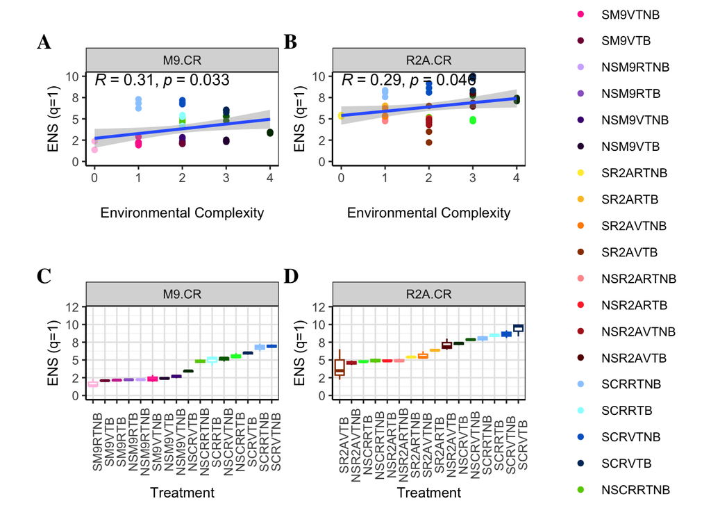

```r
combined_plot = ggarrange(regression7, regression6,hill7, hill6,  ncol = 2, nrow=2, align="hv", labels = c("A", "B",  "C", "D"), hjust=0.2, vjust=0.6, font.label = list(size = 15,family="serif"))
combined_with_padding <- ggdraw() +
  draw_plot(combined_plot, x = 0, y = 0, width = 1, height = 1) +
  theme(plot.margin = margin(t = 10, r = 0, b = 0, l = 10, unit = "mm"))

final_plot <- cowplot::plot_grid(
  combined_with_padding,
  legend_grob,
  ncol = 2,
  rel_widths = c(3, 1)
)


#svg("~/Desktop/PMXC_regression_Hill1_T12_icons.svg", height=8, width=12)

final_plot
```

```r
#dev.off()
```

#Figure 3 - GLM results observed and marginal

```r
#S.R2A.RT.NB as reference
pmxc = read.csv("~/Desktop/PMXC6_7_combined_ASVtable_OGperSample.csv", header=T)

t12 = pmxc[pmxc$Time == "T12",]

t12_6 = t12[t12$Experiment == "PMXC6",]

t12_7 = t12[t12$Experiment == "PMXC7",]

#Set reference levels for model
t12_6$Media <- factor(t12_6$Media, levels = c("R2A", "CR"))
t12_6$Temp <- factor(t12_6$Temp, levels = c("RT", "VT"))
t12_6$Shake <- factor(t12_6$Shake, levels = c("S", "NS"))
t12_6$Beads <- factor(t12_6$Beads, levels = c("NB", "B"))

t12_7$Media <- factor(t12_7$Media, levels = c("M9", "CR"))
t12_7$Temp <- factor(t12_7$Temp, levels = c("RT", "VT"))
t12_7$Shake <- factor(t12_7$Shake, levels = c("S", "NS"))
t12_7$Beads <- factor(t12_7$Beads, levels = c("NB", "B"))
```

#Run GLM on T12 usig Hill1 calculated with 1% abundance cutoff

```r
#PMXC6 (CR.R2A)

#Run GLM model
glm_pmxc6T12 <- glm(hill1  ~ Media*Shake*Temp*Beads, data=t12_6,family = Gamma(link = "log"))

summary(glm_pmxc6T12)
```

```
##
## Call:
## glm(formula = hill1 ~ Media * Shake * Temp * Beads, family = Gamma(link = "log"),
##     data = t12_6)
##
## Coefficients:
##                               Estimate Std. Error t value Pr(>|t|)
## (Intercept)                    1.68244    0.08467  19.870  < 2e-16 ***
## MediaCR                        0.39901    0.11975   3.332 0.002185 **
## ShakeNS                       -0.08768    0.11975  -0.732 0.469366
## TempVT                         0.04517    0.11975   0.377 0.708505
## BeadsB                         0.17189    0.11975   1.435 0.160861
## MediaCR:ShakeNS               -0.40257    0.16935  -2.377 0.023591 *
## MediaCR:TempVT                 0.02900    0.16935   0.171 0.865118
## ShakeNS:TempVT                -0.11360    0.16935  -0.671 0.507133
## MediaCR:BeadsB                -0.12463    0.16935  -0.736 0.467115
## ShakeNS:BeadsB                -0.17189    0.16935  -1.015 0.317701
## TempVT:BeadsB                 -0.49363    0.16935  -2.915 0.006446 **
## MediaCR:ShakeNS:TempVT         0.50968    0.23949   2.128 0.041118 *
## MediaCR:ShakeNS:BeadsB         0.10546    0.23949   0.440 0.662639
## MediaCR:TempVT:BeadsB          0.52910    0.23949   2.209 0.034433 *
## ShakeNS:TempVT:BeadsB          0.92862    0.23949   3.877 0.000494 ***
## MediaCR:ShakeNS:TempVT:BeadsB -1.01929    0.33869  -3.010 0.005070 **
## ---
## Signif. codes:  0 '***' 0.001 '**' 0.01 '*' 0.05 '.' 0.1 ' ' 1
##
## (Dispersion parameter for Gamma family taken to be 0.02150832)
##
##     Null deviance: 3.86068  on 47  degrees of freedom
## Residual deviance: 0.68716  on 32  degrees of freedom
## AIC: 140.8
##
## Number of Fisher Scoring iterations: 4
```

```r
library(sjPlot)
glm_plot6 = plot_model(glm_pmxc6T12,show.values = TRUE, show.p=TRUE, value.offset=0.4,vline="black",transform="exp", type="est")


glm_plot6 = glm_plot6 +theme(axis.line = element_line(colour = "black"),
    panel.grid.major = element_blank(),
    panel.grid.minor = element_blank(),
    panel.border = element_blank(),
    panel.background = element_blank())+scale_color_manual(values = c("black","black")) + theme(text = element_text(size = 10)) + ggtitle("R2A.CR") + coord_flip(clip = "off")+ scale_y_log10(limits = c(0.1, 10))
```

```
## replace the existing one.
```

```r
glm_plot_int6 = plot_model(glm_pmxc6T12,show.values = TRUE, show.p=TRUE, value.offset=0.3,vline="black", type="int")


glm_int6 <- glm_plot_int6[[11]]

plot_data6 <- glm_int6$data

# Step 2: Create a new 'Media' column based on x
plot_data6$Media <- factor(ifelse(plot_data6$x == 1, "R2A", "CR"), levels = c("R2A", "CR"))

# Step 3: Create the plot colored by Media
glm_plot_int6 <- ggplot(plot_data6, aes(x = group, y = predicted, color = Media)) +
  geom_point(position = position_dodge(width = 0.3), size = 2.5) +
  geom_errorbar(aes(ymin = conf.low, ymax = conf.high), width = 0.2, position = position_dodge(width = 0.3)) +
  facet_grid(panel ~ facet) +
  theme_bw() +
  scale_color_manual(values = c("R2A" = "orange", "CR" = "darkgreen")) +
  theme(
    axis.line = element_line(colour = "black"),
    panel.border = element_rect(color = "black", fill = NA),
    strip.background = element_rect(fill = "grey90", colour = "black")
  )+ ylab("ENS (q=1)")+xlab("Shake") + ggtitle("Effect plots for R2A.CR")
```

```r
#PMXC7 (CR.M9)

#Run GLM model
glm_pmxc7T12 <- glm(hill1  ~Media*Shake*Temp*Beads, data=t12_7,family = Gamma(link = "log"))

summary(glm_pmxc7T12)
```

```
##
## Call:
## glm(formula = hill1 ~ Media * Shake * Temp * Beads, family = Gamma(link = "log"),
##     data = t12_7)
##
## Coefficients:
##                               Estimate Std. Error t value Pr(>|t|)
## (Intercept)                    0.53011    0.06671   7.946 4.54e-09 ***
## MediaCR                        1.38445    0.09435  14.674 9.21e-16 ***
## ShakeNS                        0.27075    0.09435   2.870 0.007223 **
## TempVT                         0.32362    0.09435   3.430 0.001682 **
## BeadsB                         0.22349    0.09435   2.369 0.024049 *
## MediaCR:ShakeNS               -0.61124    0.13343  -4.581 6.68e-05 ***
## MediaCR:TempVT                -0.30053    0.13343  -2.252 0.031286 *
## ShakeNS:TempVT                -0.14552    0.13343  -1.091 0.283580
## MediaCR:BeadsB                -0.53825    0.13343  -4.034 0.000318 ***
## ShakeNS:BeadsB                -0.23071    0.13343  -1.729 0.093432 .
## TempVT:BeadsB                 -0.33708    0.13343  -2.526 0.016669 *
## MediaCR:ShakeNS:TempVT         0.17985    0.18869   0.953 0.347666
## MediaCR:ShakeNS:BeadsB         0.69094    0.18869   3.662 0.000896 ***
## MediaCR:TempVT:BeadsB          0.49501    0.18869   2.623 0.013227 *
## ShakeNS:TempVT:BeadsB          0.24742    0.18869   1.311 0.199113
## MediaCR:ShakeNS:TempVT:BeadsB -0.96022    0.26685  -3.598 0.001066 **
## ---
## Signif. codes:  0 '***' 0.001 '**' 0.01 '*' 0.05 '.' 0.1 ' ' 1
##
## (Dispersion parameter for Gamma family taken to be 0.013352)
##
##     Null deviance: 11.09463  on 47  degrees of freedom
## Residual deviance:  0.40835  on 32  degrees of freedom
## AIC: 59.348
##
## Number of Fisher Scoring iterations: 4
```

```r
library(sjPlot)
glm_plot7 = plot_model(glm_pmxc7T12,show.values = TRUE, show.p=TRUE, value.offset=0.4,vline="black",transform="exp", type="est")


glm_plot7 = glm_plot7 +theme(axis.line = element_line(colour = "black"),
    panel.grid.major = element_blank(),
    panel.grid.minor = element_blank(),
    panel.border = element_blank(),
    panel.background = element_blank(),plot.margin = margin(t = 10, r = 10, b = 10, l = 10, unit = "pt"))+scale_color_manual(values = c("black","black")) + theme(text = element_text(size = 10)) + ggtitle("M9.CR")+
  coord_flip(clip = "off") + scale_y_log10(limits = c(0.1, 10))
```

```
## replace the existing one.
```

```r
glm_plot_int7 = plot_model(glm_pmxc7T12,show.values = TRUE, show.p=TRUE, value.offset=0.3,vline="black", type="int")


glm_int7 <- glm_plot_int7[[11]]

plot_data7 <- glm_int7$data

# Step 2: Create a new 'Media' column based on x
plot_data7$Media <- factor(ifelse(plot_data7$x == 1, "M9", "CR"), levels = c("M9", "CR"))

# Step 3: Create the plot colored by Media
glm_plot_int7 <- ggplot(plot_data7, aes(x = group, y = predicted, color = Media)) +
  geom_point(position = position_dodge(width = 0.3), size = 2.5) +
  geom_errorbar(aes(ymin = conf.low, ymax = conf.high), width = 0.2, position = position_dodge(width = 0.3)) +
  facet_grid(panel ~ facet) +
  theme_bw() +
  scale_color_manual(values = c("M9" = "purple", "CR" = "darkgreen")) +
  theme(
    axis.line = element_line(colour = "black"),
    panel.border = element_rect(color = "black", fill = NA),
    strip.background = element_rect(fill = "grey90", colour = "black")
  ) + ylab("ENS (q=1)") +xlab("Shake") + ggtitle("Effect plots for M9.CR")
```

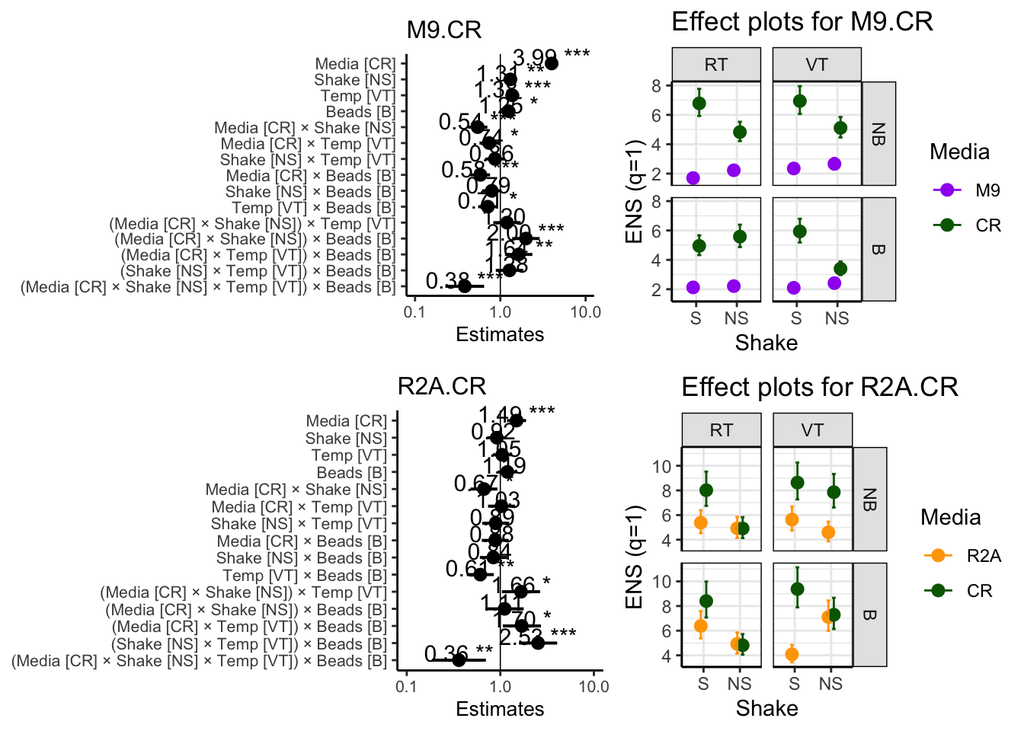

```r
library(svglite)

#svglite("~/Desktop/PMXC_GLM_estimates_intPred_T12_min0.01_stacked_v2.svg", height=10, width=12)

layout_matrix <- matrix(c(1,1,1,2, 2,
                         3,3,3,4,4),
                       nrow = 2,
                       byrow = TRUE)


grid.arrange(glm_plot7, glm_plot_int7,glm_plot6, glm_plot_int6, layout_matrix= layout_matrix)
```

```r
#dev.off()
```

#Figure 4 - NMDS plot & final community composition

#Calculate bray curtis with relative abundance

```r
pmxc = read.csv("~/Desktop/PMXC6_7_combined_ASVtable.csv", header=T)

#Subset by experiment and set treatment order for barplots

pmxc$Day = as.factor(pmxc$Day)

pmxc6 = pmxc[pmxc$Experiment == "PMXC6",]

pmxc6$Treatment <- factor(pmxc6$Treatment, levels = c("R2A", "CR", "SR2ARTNB", "SR2ARTB", "SR2AVTNB", "SR2AVTB","NSR2ARTNB", "NSR2ARTB", "NSR2AVTNB", "NSR2AVTB", "SCRRTNB", "SCRRTB", "SCRVTNB", "SCRVTB","NSCRRTNB", "NSCRRTB", "NSCRVTNB", "NSCRVTB"))

pmxc7 = pmxc[pmxc$Experiment == "PMXC7",]

pmxc7$Treatment <- factor(pmxc7$Treatment, levels = c("M9", "CR", "SM9RTNB", "SM9RTB", "SM9VTNB", "SM9VTB","NSM9RTNB", "NSM9RTB", "NSM9VTNB", "NSM9VTB", "SCRRTNB", "SCRRTB", "SCRVTNB", "SCRVTB","NSCRRTNB", "NSCRRTB", "NSCRVTNB", "NSCRVTB"))
```

```r
#Subset ASV abundances and save as matrix
abund_table6 <- as.matrix(pmxc6[,2:29])
abund_table7 <- as.matrix(pmxc7[,2:29])

#Subset metadata and save as matrix
meta_table6 <- pmxc6[,30:43]
meta_table7 <- pmxc7[,30:43]

#Calculate Bray-Curtis dissimilarity
nmds6 = metaMDS(abund_table6, distance = "bray")
```

```
## *** Best solution was not repeated -- monoMDS stopping criteria:
##      7: stress ratio > sratmax
##     13: scale factor of the gradient < sfgrmin
```

```r
nmds7 = metaMDS(abund_table7, distance = "bray")
```

```
## *** Best solution was not repeated -- monoMDS stopping criteria:
##     13: stress ratio > sratmax
##      7: scale factor of the gradient < sfgrmin
```

#Organize NMDS scores in data frame with metadata

```r
data.scores6 = as.data.frame(scores(nmds6)$sites)

#add columns to data frame
data.scores6$Sample = meta_table6$Sample
data.scores6$Time = meta_table6$Time
data.scores6$Media = meta_table6$Media
data.scores6$Treatment = meta_table6$Treatment
data.scores6$Beads = meta_table6$Beads
data.scores6$Shake = meta_table6$Shake
data.scores6$Temp = meta_table6$Temp
data.scores6$Rep = meta_table6$Rep
data.scores6$Day = meta_table6$Day

head(data.scores6)
```

```
##          NMDS1       NMDS2 Time Media Treatment Beads Shake Temp  Rep Day
## 1 -0.001626321 -0.96974089   OG    CR        CR  <NA>  <NA> <NA> <NA>   0
## 2  0.187183880 -0.71633080   OG   R2A       R2A  <NA>  <NA> <NA> <NA>   0
## 3  0.105402217  0.02603987   T0    CR   NSCRRTB     B    NS   RT REP1   3
## 4  0.051455062  0.01535630   T0    CR   NSCRRTB     B    NS   RT REP2   3
## 5 -0.132987361 -0.15554331   T0    CR   NSCRRTB     B    NS   RT REP3   3
## 6 -0.178000258 -0.04813972   T0    CR   NSCRVTB     B    NS   VT REP1   3
```

```r
data.scores7 = as.data.frame(scores(nmds7)$sites)

#add columns to data frame
data.scores7$Sample = meta_table7$Sample
data.scores7$Time = meta_table7$Time
data.scores7$Media = meta_table7$Media
data.scores7$Treatment = meta_table7$Treatment
data.scores7$Beads = meta_table7$Beads
data.scores7$Shake = meta_table7$Shake
data.scores7$Temp = meta_table7$Temp
data.scores7$Rep = meta_table7$Rep
data.scores7$Day = meta_table7$Day

head(data.scores7)
```

```
##           NMDS1      NMDS2 Time Media Treatment Beads Shake Temp  Rep Day
## 612 -0.69598318 -1.1925914   OG    CR        CR  <NA>  <NA> <NA> <NA>   0
## 613 -0.70088680 -1.1622240   OG    M9        M9  <NA>  <NA> <NA> <NA>   0
## 614  0.02449930  0.1684287   T0    CR   NSCRRTB     B    NS   RT REP1   3
## 615 -0.03492859  0.1616027   T0    CR   NSCRRTB     B    NS   RT REP2   3
## 616  0.01881928  0.1942499   T0    CR   NSCRRTB     B    NS   RT REP3   3
## 617  0.10488492  0.3024633   T0    CR   NSCRVTB     B    NS   VT REP1   3
```

#NMDS showing only centroids for OG, T0, T12

```r
og_6 = subset(data.scores6, Time == "OG")
t0_6= subset(data.scores6, Time == "T0")
t12_6= subset(data.scores6, Time == "T12")

scores6=rbind(og_6,t0_6,t12_6)

og_7 = subset(data.scores7, Time == "OG")
t0_7= subset(data.scores7, Time == "T0")
t12_7= subset(data.scores7, Time == "T12")

scores7=rbind(og_7,t0_7,t12_7)
```

```r
#data.scores = na.omit(data.scores)
centroids6 <- aggregate(cbind(NMDS1, NMDS2) ~ Treatment + Day,
                       data = scores6,
                       FUN = mean)
centroidOG_6 = og_6
centroid1_6 = centroids6[centroids6$Day=="3",]
centroid2_6 = centroids6[centroids6$Day=="39",]

# Step 7: Plot the NMDS with centroids

scores6$Day = as.factor(scores6$Day)

nmdsplot6 = ggplot(scores6, aes(x = NMDS1, y = NMDS2), color = Treatment) +
  geom_point(alpha = 0.2, aes(color = Treatment, shape=Day), size=4) +  # Show individual points
  geom_point(data = centroid1_6, aes(x = NMDS1, y = NMDS2, color = Treatment, shape=Day), size = 8) +
  geom_point(data = centroid2_6, aes(x = NMDS1, y = NMDS2, color = Treatment, shape=Day), size = 8)+
  geom_point(data = centroidOG_6, aes(x = NMDS1, y = NMDS2, color = Treatment, shape=Day), size = 8)+ scale_shape_manual(values=c(8,19,17))+
  theme_minimal() +scale_color_manual(values = color) + theme(axis.line = element_line(colour = "black"),
    panel.grid.major = element_blank(),
    panel.grid.minor = element_blank(),
    panel.border = element_blank(),
    panel.background = element_blank(), legend.position="none", legend.box="vertical", legend.margin=margin(),legend.title = element_text(angle = 90, vjust=1), plot.margin = margin(t = 20, r = 20, b = 20, l = 20, unit = "pt"), axis.text=element_text(size=15), axis.title.y = element_text(size = 15), axis.title.x = element_text(size = 15)) + ggtitle("R2A.CR")+ annotate("text", x = Inf, y = -Inf, label = sprintf("Stress = %.2f", nmds6$stress),
           hjust = 1.1, vjust = -0.5, size = 6)

#data.scores = na.omit(data.scores)
centroids_7 <- aggregate(cbind(NMDS1, NMDS2) ~ Treatment + Day,
                       data = scores7,
                       FUN = mean)
centroidOG_7 = og_7
centroid1_7 = centroids_7[centroids_7$Day=="3",]
centroid2_7 = centroids_7[centroids_7$Day=="39",]

# Step 7: Plot the NMDS with centroids
scores7$Day = as.factor(scores7$Day)



nmdsplot7 = ggplot(scores7, aes(x = NMDS1, y = NMDS2), color = Treatment) +
  geom_point(alpha = 0.2, aes(color = Treatment, shape=Day), size=4) +  # Show individual points
  geom_point(data = centroid1_7, aes(x = NMDS1, y = NMDS2, color = Treatment, shape=Day), size = 8) +
  geom_point(data = centroid2_7, aes(x = NMDS1, y = NMDS2, color = Treatment, shape=Day), size = 8)+
  geom_point(data = centroidOG_7, aes(x = NMDS1, y = NMDS2, color = Treatment, shape=Day), size = 8)+ scale_shape_manual(values=c(8,19,17))+
  theme_minimal() +scale_color_manual(values = color) + theme(axis.line = element_line(colour = "black"),
    panel.grid.major = element_blank(),
    panel.grid.minor = element_blank(),
    panel.border = element_blank(),
    panel.background = element_blank(), legend.position="none", legend.box="vertical", legend.margin=margin(),legend.title = element_text(angle = 90, vjust=1), plot.margin = margin(t = 20, r = 20, b = 20, l = 20, unit = "pt"), axis.text=element_text(size=15), axis.title.y = element_text(size = 15), axis.title.x = element_text(size = 15)) + ggtitle("M9.CR") + annotate("text", x = Inf, y = -Inf, label = sprintf("Stress = %.2f", nmds7$stress),
           hjust = 1.1, vjust = -0.5, size = 6)
```

```r
#Make nmds plot with both pmxc6 and pmxc7 and extract legend

scores = rbind(scores6, scores7)

scores$Day = factor(scores$Day, levels = c("0", "3", "39"))


scores$Treatment = factor(scores$Treatment, levels = c("SR2ARTNB", "SR2ARTB", "SR2AVTNB", "SR2AVTB","NSR2ARTNB", "NSR2ARTB", "NSR2AVTNB", "NSR2AVTB", "SM9RTNB", "SM9RTB", "SM9VTNB", "SM9VTB","NSM9RTNB", "NSM9RTB", "NSM9VTNB", "NSM9VTB",  "SCRRTNB", "SCRRTB", "SCRVTNB", "SCRVTB","NSCRRTNB", "NSCRRTB", "NSCRVTNB", "NSCRVTB", "CR", "R2A", "M9"))



# Build the plot
nmds_legend_plot <- ggplot(scores, aes(x = NMDS1, y = NMDS2), color = Treatment) +
  geom_point(aes(color = Treatment, shape=Day), size=8) +  # Show individual point
  theme_minimal() +scale_color_manual(values = color)  +
  theme(
    legend.position = "right",
    legend.box.margin = margin(0, 0, 0, 0),  # Reduce margin around the entire legend box
    legend.spacing.y = unit(0.5, "pt"),  # Reduce vertical space between legend items
    legend.spacing.x = unit(1, "pt"),  # Reduce horizontal space between legend items
    legend.key.size = unit(2.5, "lines"),  # Reduce size of legend keys
    legend.title.align = 0.5,
    legend.text = element_text(size = 15),        # <- Increase legend text size
    legend.title = element_text(size = 15)
  )+ scale_shape_manual(values=c(8,19,17))


# Convert to grob
g <- ggplotGrob(nmds_legend_plot)

# Extract legend manually
nmds_legend <- g$grobs[which(sapply(g$grobs, function(x) x$name) == "guide-box")][[1]]
```

#Barplot final samples

```r
t12_6=pmxc6[pmxc6$Time=="T12",]
t12_7=pmxc7[pmxc7$Time=="T12",]

#Melt data into long format for barplot
long6 = reshape2::melt(t12_6, variable.name="Isolate", id.vars = c("Sample", "Time",  "Shake", "Media", "Temp", "Beads", "Rep", "Treatment", "ComplexityB", "Experiment", "ID", "Day", "hill0", "hill1", "hill2"))

long6$Isolate <- as.character(long6$Isolate)

#Melt data into long format for barplot
long7 = reshape2::melt(t12_7, variable.name="Isolate", id.vars = c("Sample", "Time",  "Shake", "Media", "Temp", "Beads", "Rep", "Treatment", "ComplexityB", "Experiment", "ID", "Day", "hill0", "hill1", "hill2"))

long7$Isolate <- as.character(long7$Isolate)

# Define the desired order of ASVs
ordered_asvs6 <- c("S9", "S33", "S8", "S120", "S14",
                   "S29", "S30", "S21", "S11", "S5", "S16", "S7", "S32", "S6", "S22", "S491", "S31", "S27", "S10", "S391", "S34", "S263", "S17", "S28", "S2", "S19", "Unassigned", "Rare")

ordered_asvs7 <- c("S9", "S8", "S120", "S14",
                   "S29", "S30", "S21", "S11", "S5", "S16", "S7", "S32", "S6", "S22", "S491", "S31", "S27", "S10", "S391", "S34", "S263", "S17", "S28", "S2", "S19", "Unassigned", "Rare")

# Set the factor levels in desired order
long6$Isolate <- factor(long6$Isolate, levels = ordered_asvs6)
long7$Isolate <- factor(long7$Isolate, levels = ordered_asvs7)


comp6 = ggplot(data = long6, aes(fill=Isolate, y=value, x=Rep)) +
  theme_bw()+
    geom_bar(position="fill", stat="identity") +
   scale_fill_manual(values = col28) + theme(strip.text = element_text(
    size =10)) +theme(axis.text=element_text(size=15), legend.text = element_text(size=15),legend.key.size = unit(5, 'mm'), axis.text.x = element_text(angle = 90),  axis.title.x=element_blank(), plot.margin = margin(t = 20, r = 20, b = 20, l = 20, unit = "pt"),
    axis.title.y = element_text(size = 15))+ ylab("Relative Abundance") + guides(fill=guide_legend(ncol =1)) + facet_wrap(~Treatment)+ theme(legend.position="none", strip.text = element_text(size = 15))+ ggtitle("R2A.CR")

comp7 = ggplot(data = long7, aes(fill=Isolate, y=value, x=Rep)) +
  theme_bw()+
    geom_bar(position="fill", stat="identity") +
   scale_fill_manual(values = col28) + theme(strip.text = element_text(
    size =10)) +theme(axis.text=element_text(size=15), legend.text = element_text(size=15),legend.key.size = unit(5, 'mm'), axis.text.x = element_text(angle = 90),  axis.title.x=element_blank(), plot.margin = margin(t = 20, r = 20, b = 20, l = 20, unit = "pt"), axis.title.y = element_text(size = 15))+ ylab("Relative Abundance") + guides(fill=guide_legend(ncol =1)) + facet_wrap(~Treatment)+ theme(legend.position="none", strip.text = element_text(size = 15)) + ggtitle("M9.CR")
```

#Extract legend for barplot

```r
comp_legend_plot = ggplot(data = long6, aes(fill=Isolate, y=value, x=Rep)) +
  theme_bw()+
    geom_bar(position="fill", stat="identity") +
   scale_fill_manual(values = col28) + theme(strip.text = element_text(
    size =8)) +theme(axis.text=element_text(size=8), legend.text = element_text(size=10), axis.text.x = element_text(angle = 90),  axis.title.x=element_blank(), plot.margin = margin(t = 10, r = 10, b = 10, l = 10, unit = "pt"))+ ylab("Relative Abundance") + guides(fill = guide_legend(ncol = 2)) + facet_wrap(~Treatment)+ theme(
    legend.position = "right",
    legend.box.margin = margin(0, 0, 0, 0),  # Reduce margin around the entire legend box
    legend.spacing.y = unit(0.5, "pt"),  # Reduce vertical space between legend items
    legend.spacing.x = unit(1, "pt"),  # Reduce horizontal space between legend items
    legend.key.size = unit(3, "lines"),  # Reduce size of legend keys
    legend.title.align = 0.5,
    legend.text = element_text(size = 15),        # <- Increase legend text size
    legend.title = element_text(size = 15)
    )



# Convert to grob
g <- ggplotGrob(comp_legend_plot)

# Extract legend manually
comp_legend <- g$grobs[which(sapply(g$grobs, function(x) x$name) == "guide-box")][[1]]
```

[figure not shown]

```r
#svg("~/Desktop/PMXC6_PMXC7_T12composition_nmds_v2.svg", width=25, height=20)
ggarrange(nmdsplot7, nmdsplot6, nmds_legend, comp7, comp6, comp_legend, align = "hv")
```

```r
#dev.off()
```

#Figure 5 - ANCOMBC dot plot

```r
library(phyloseq)
library(ANCOMBC)
```

```r
data6 = read.csv("~/Desktop/PMXC6_ASVtable_rawCounts_notRare_summedASVs_metadata.csv", header=T)

data6 = data6[data6$Time == c("T12"),]

abun6 = data6[,2:28]
metadata6 = data6[,29:37]

rownames(metadata6) = data6$Sample
rownames(abun6) = data6$Sample


tabun6 = t(abun6)

OTU6 = otu_table(as.matrix(tabun6), taxa_are_rows = TRUE)
physeq6 = phyloseq(OTU6)

taxmat6 = matrix(sample(letters, 70, replace = TRUE), nrow = nrow(OTU6), ncol = 7)
rownames(taxmat6) <- rownames(OTU6)
colnames(taxmat6) <- c("Domain", "Phylum", "Class", "Order", "Family", "Genus", "Species")
taxmat6
```

```
##            Domain Phylum Class Order Family Genus Species
## ASV10      "x"    "n"    "k"   "w"   "f"    "r"   "z"
## ASV11      "y"    "f"    "a"   "v"   "u"    "w"   "w"
## ASV14      "c"    "p"    "p"   "d"   "f"    "i"   "o"
## ASV16      "c"    "g"    "i"   "m"   "p"    "j"   "l"
## ASV17      "w"    "t"    "n"   "y"   "a"    "x"   "u"
## ASV19      "l"    "e"    "l"   "k"   "n"    "x"   "n"
## ASV2       "b"    "h"    "w"   "i"   "d"    "y"   "f"
## ASV21      "f"    "p"    "o"   "o"   "d"    "c"   "p"
## ASV22      "u"    "f"    "a"   "b"   "e"    "c"   "g"
## ASV27      "d"    "c"    "c"   "h"   "r"    "w"   "t"
## ASV28      "p"    "i"    "e"   "y"   "u"    "l"   "e"
## ASV29      "w"    "f"    "r"   "z"   "r"    "b"   "h"
## ASV30      "v"    "u"    "w"   "w"   "d"    "f"   "p"
## ASV31      "d"    "f"    "i"   "o"   "q"    "u"   "f"
## ASV32      "m"    "p"    "j"   "l"   "i"    "d"   "c"
## ASV33      "y"    "a"    "x"   "u"   "h"    "p"   "i"
## ASV34      "k"    "n"    "x"   "n"   "k"    "w"   "f"
## ASV5       "i"    "d"    "y"   "f"   "a"    "v"   "u"
## ASV6       "o"    "d"    "c"   "p"   "p"    "d"   "f"
## ASV7       "b"    "e"    "c"   "g"   "i"    "m"   "p"
## ASV8       "h"    "r"    "w"   "t"   "n"    "y"   "a"
## ASV9       "y"    "u"    "l"   "e"   "l"    "k"   "n"
## Unassigned "z"    "r"    "b"   "h"   "w"    "i"   "d"
## X120       "w"    "d"    "f"   "p"   "o"    "o"   "d"
## X263       "o"    "q"    "u"   "f"   "a"    "b"   "e"
## X391       "l"    "i"    "d"   "c"   "c"    "h"   "r"
## X491       "u"    "h"    "p"   "i"   "e"    "y"   "u"
```

```r
TAX6 = tax_table(taxmat6)

physeq6 = phyloseq(OTU6, TAX6)
physeq6
```

```
## phyloseq-class experiment-level object
## otu_table()   OTU Table:         [ 27 taxa and 48 samples ]
## tax_table()   Taxonomy Table:    [ 27 taxa by 7 taxonomic ranks ]
```

```r
meta6 = sample_data(metadata6)

meta6$Shake <- factor(meta6$Shake, levels=c("S", "NS"))
meta6$Media <- factor(meta6$Media, levels=c("R2A", "CR"))
meta6$Temp <- factor(meta6$Temp, levels=c("RT", "VT"))
meta6$Beads <- factor(meta6$Beads, levels=c("NB", "B"))
meta6$Treatment <- factor(meta6$Treatment, levels=c("SR2ARTNB", "SR2AVTNB", "SR2AVTB", "SR2ARTB", "SCRVTNB", "SCRVTB", "SCRRTNB", "SCRRTB", "NSR2AVTNB", "NSR2AVTB", "NSR2ARTNB", "NSR2ARTB", "NSCRVTNB", "NSCRVTB", "NSCRRTNB", "NSCRRTB"))


physeq6 = merge_phyloseq(physeq6, meta6)
physeq6
```

```
## phyloseq-class experiment-level object
## otu_table()   OTU Table:         [ 27 taxa and 48 samples ]
## sample_data() Sample Data:       [ 48 samples by 9 sample variables ]
## tax_table()   Taxonomy Table:    [ 27 taxa by 7 taxonomic ranks ]
```

```r
output6 = ancombc2(data = physeq6, assay_name = "counts", tax_level = NULL,
                       fix_formula = "Media * Shake * Temp * Beads",
                       p_adj_method = "fdr", pseudo_sens = TRUE,
                       prv_cut = 0.1,#change as needed, here prvcut set to only include ASV in 10 percent of samples, default is 30%
                       alpha = 0.05, n_cl = 3, verbose = TRUE)
```

```
## Checking the input data type ...
```

```
## The input data is of type: phyloseq
```

```
## PASS
```

```
## Checking the sample metadata ...
```

```
## The specified variables in the formula: Media, Shake, Temp, Beads
```

```
## The available variables in the sample metadata: Experiment, Shake, Media, Beads, Temp, Rep, Time, Day, Treatment
```

```
## PASS
```

```
## Checking other arguments ...
```

```
## PASS
```

```
## Obtaining initial estimates ...
```

```
## Estimating sample-specific biases ...
```

```
## ANCOM-BC2 primary results ...
```

```
## Conducting sensitivity analysis for pseudo-count addition to 0s ...
## For taxa that are significant but do not pass the sensitivity analysis,
## they are marked in the 'passed_ss' column and will be treated as non-significant in the 'diff_robust' column.
## For detailed instructions on performing sensitivity analysis, please refer to the package vignette.
```

```r
output6_res <- output6$res
dim(output6_res)
```

```
## [1]  21 129
```

```r
#Ensuring all ASVs are included on y-axis
full_asv_list <- data.frame(taxon = taxa_names(physeq6))

full_res6 <- full_asv_list %>%
  left_join(output6_res, by = "taxon")

full_res6 <- full_res6 %>%
  mutate(across(starts_with("diff_"), ~replace_na(., FALSE))) %>%
  mutate(across(starts_with("lfc_"), ~replace_na(., NA_real_)))

library(tidyverse)

# Step 1: Prepare LFC, SE, significance
lfc_df <- full_res6 %>%
  select(taxon, starts_with("lfc_")) %>%
  pivot_longer(-taxon, names_to = "term", values_to = "lfc") %>%
  mutate(term = str_remove(term, "^lfc_"))

sig_df <- full_res6 %>%
  select(taxon, starts_with("diff_")) %>%
  pivot_longer(-taxon, names_to = "term", values_to = "significant") %>%
  mutate(term = str_remove(term, "^diff_"))

# Step 2: Merge, replace non-significant lfc with NA
plot_df6 <- lfc_df %>%
  left_join(sig_df, by = c("taxon", "term")) %>%
  filter(term != "(Intercept)") %>%
  mutate(
    lfc = ifelse(significant, lfc, NA),
    term = str_replace_all(term, ":", " × ")  # for prettier facet labels
  )

# Step 3: Ensure factor levels to include all taxa and terms on axes
plot_df6$taxon <- factor(plot_df6$taxon, levels = unique(plot_df6$taxon))
plot_df6$term <- factor(plot_df6$term, levels = unique(plot_df6$term))
```

```r
data7 = read.csv("~/Desktop/PMXC7_ASVtable_rawCounts_notRare_summedASVs_metadata.csv", header=T)

data7 = data7[data7$Time == "T12",]

abun7 = data7[,2:27]
metadata7 = data7[,28:36]

rownames(metadata7) = data7$Sample
rownames(abun7) = data7$Sample


tabun7 = t(abun7)

OTU7 = otu_table(as.matrix(tabun7), taxa_are_rows = TRUE)
physeq7 = phyloseq(OTU7)

taxmat7 = matrix(sample(letters, 70, replace = TRUE), nrow = nrow(OTU7), ncol = 7)
rownames(taxmat7) <- rownames(OTU7)
colnames(taxmat7) <- c("Domain", "Phylum", "Class", "Order", "Family", "Genus", "Species")
taxmat7
```

```
##           Domain Phylum Class Order Family Genus Species
## ASV10     "i"    "g"    "y"   "q"   "w"    "b"   "v"
## ASV11     "a"    "f"    "f"   "z"   "u"    "r"   "k"
## ASV14     "e"    "t"    "a"   "x"   "e"    "j"   "n"
## ASV16     "l"    "e"    "k"   "d"   "e"    "u"   "a"
## ASV17     "p"    "v"    "k"   "a"   "c"    "c"   "p"
## ASV19     "l"    "i"    "e"   "y"   "e"    "f"   "x"
## ASV2      "c"    "g"    "f"   "b"   "a"    "i"   "a"
## ASV21     "t"    "v"    "c"   "o"   "j"    "t"   "h"
## ASV22     "q"    "w"    "b"   "v"   "g"    "r"   "r"
## ASV27     "z"    "u"    "r"   "k"   "j"    "y"   "g"
## ASV28     "x"    "e"    "j"   "n"   "g"    "i"   "g"
## ASV29     "d"    "e"    "u"   "a"   "q"    "a"   "f"
## ASV30     "a"    "c"    "c"   "p"   "o"    "e"   "t"
## ASV31     "y"    "e"    "f"   "x"   "e"    "l"   "e"
## ASV32     "b"    "a"    "i"   "a"   "f"    "p"   "v"
## ASV34     "o"    "j"    "t"   "h"   "f"    "l"   "i"
## ASV5      "v"    "g"    "r"   "r"   "a"    "c"   "g"
## ASV6      "k"    "j"    "y"   "g"   "c"    "t"   "v"
## ASV7      "n"    "g"    "i"   "g"   "y"    "q"   "w"
## ASV8      "a"    "q"    "a"   "f"   "f"    "z"   "u"
## ASV9      "p"    "o"    "e"   "t"   "a"    "x"   "e"
## Unassigne "x"    "e"    "l"   "e"   "k"    "d"   "e"
## X120      "a"    "f"    "p"   "v"   "k"    "a"   "c"
## X263      "h"    "f"    "l"   "i"   "e"    "y"   "e"
## X391      "r"    "a"    "c"   "g"   "f"    "b"   "a"
## X491      "g"    "c"    "t"   "v"   "c"    "o"   "j"
```

```r
TAX7 = tax_table(taxmat7)

physeq7 = phyloseq(OTU7, TAX7)
physeq7
```

```
## phyloseq-class experiment-level object
## otu_table()   OTU Table:         [ 26 taxa and 48 samples ]
## tax_table()   Taxonomy Table:    [ 26 taxa by 7 taxonomic ranks ]
```

```r
meta7 = sample_data(metadata7)

meta7$Shake <- factor(meta7$Shake, levels=c("S", "NS"))
meta7$Media <- factor(meta7$Media, levels=c("M9", "CR"))
meta7$Temp <- factor(meta7$Temp, levels=c("RT", "VT"))
meta7$Beads <- factor(meta7$Beads, levels=c("NB", "B"))
meta7$Treatment <- factor(meta7$Treatment, levels=c("SM9RTNB", "SM9VTNB", "SM9VTB", "SM9RTB", "SCRVTNB", "SCRVTB", "SCRRTNB", "SCRRTB", "NSM9VTNB", "NSM9VTB", "NSM9RTNB", "NSM9RTB", "NSCRVTNB", "NSCRVTB", "NSCRRTNB", "NSCRRTB"))


physeq7 = merge_phyloseq(physeq7, meta7)
physeq7
```

```
## phyloseq-class experiment-level object
## otu_table()   OTU Table:         [ 26 taxa and 48 samples ]
## sample_data() Sample Data:       [ 48 samples by 9 sample variables ]
## tax_table()   Taxonomy Table:    [ 26 taxa by 7 taxonomic ranks ]
```

```r
output7 = ancombc2(data = physeq7, assay_name = "counts", tax_level = NULL,
                       fix_formula = "Media * Shake * Temp * Beads",
                       p_adj_method = "fdr", pseudo_sens = TRUE,
                       prv_cut = 0.1,#change as needed, here prvcut set to only include ASV in 10 percent of samples, default is 30%
                       alpha = 0.05, n_cl = 3, verbose = TRUE)
```

```
## Checking the input data type ...
```

```
## The input data is of type: phyloseq
```

```
## PASS
```

```
## Checking the sample metadata ...
```

```
## The specified variables in the formula: Media, Shake, Temp, Beads
```

```
## The available variables in the sample metadata: Experiment, Shake, Media, Beads, Temp, Rep, Time, Day, Treatment
```

```
## PASS
```

```
## Checking other arguments ...
```

```
## PASS
```

```
## Obtaining initial estimates ...
```

```
## Estimating sample-specific biases ...
```

```
## ANCOM-BC2 primary results ...
```

```
## Conducting sensitivity analysis for pseudo-count addition to 0s ...
## For taxa that are significant but do not pass the sensitivity analysis,
## they are marked in the 'passed_ss' column and will be treated as non-significant in the 'diff_robust' column.
## For detailed instructions on performing sensitivity analysis, please refer to the package vignette.
```

```r
output7_res <- output7$res
dim(output7_res)
```

```
## [1]  22 129
```

```r
#Ensuring all ASVs are included on y-axis
full_asv_list <- data.frame(taxon = taxa_names(physeq6))

full_res7 <- full_asv_list %>%
  left_join(output7_res, by = "taxon")

full_res7 <- full_res7 %>%
  mutate(across(starts_with("diff_"), ~replace_na(., FALSE))) %>%
  mutate(across(starts_with("lfc_"), ~replace_na(., NA_real_)))

library(tidyverse)

# Step 1: Prepare LFC, SE, significance
lfc_df <- full_res7 %>%
  select(taxon, starts_with("lfc_")) %>%
  pivot_longer(-taxon, names_to = "term", values_to = "lfc") %>%
  mutate(term = str_remove(term, "^lfc_"))

sig_df <- full_res7 %>%
  select(taxon, starts_with("diff_")) %>%
  pivot_longer(-taxon, names_to = "term", values_to = "significant") %>%
  mutate(term = str_remove(term, "^diff_"))

# Step 2: Merge, replace non-significant lfc with NA
plot_df7 <- lfc_df %>%
  left_join(sig_df, by = c("taxon", "term")) %>%
  filter(term != "(Intercept)") %>%
  mutate(
    lfc = ifelse(significant, lfc, NA),
    term = str_replace_all(term, ":", " × ")  # for prettier facet labels
  )

# Step 3: Ensure factor levels to include all taxa and terms on axes
plot_df7$taxon <- factor(plot_df7$taxon, levels = unique(plot_df7$taxon))
plot_df7$term <- factor(plot_df7$term, levels = unique(plot_df7$term))
```

```r
library(phyloseq)
library(tidyverse)

# Step 1: Convert to relative abundance
physeq_rel6 <- transform_sample_counts(physeq6, function(x) x / sum(x))

# Step 2: Extract OTU table and ensure taxa are in rows
otu_mat6 <- as(otu_table(physeq_rel6), "matrix")
if (!taxa_are_rows(physeq_rel6)) {
  otu_mat6 <- t(otu_mat6)
}

# Step 3: Compute average relative abundance per taxon
avg_abund_df6 <- rowMeans(otu_mat6, na.rm = TRUE) %>%
  enframe(name = "taxon", value = "mean_relative_abundance") %>%
  arrange(desc(mean_relative_abundance))

# Step 1: Convert to relative abundance
physeq_rel7 <- transform_sample_counts(physeq7, function(x) x / sum(x))

# Step 2: Extract OTU table and ensure taxa are in rows
otu_mat7 <- as(otu_table(physeq_rel7), "matrix")
if (!taxa_are_rows(physeq_rel7)) {
  otu_mat7 <- t(otu_mat7)
}

# Step 3: Compute average relative abundance per taxon
avg_abund_df7 <- rowMeans(otu_mat7, na.rm = TRUE) %>%
  enframe(name = "taxon", value = "mean_relative_abundance") %>%
  arrange(desc(mean_relative_abundance))
```

```r
plot_df6$Experiment <- "R2A.CR"
plot_df7$Experiment <- "M9.CR"

plot_df6 <- plot_df6 %>%
  left_join(avg_abund_df6, by = "taxon")

plot_df7 <- plot_df7 %>%
  left_join(avg_abund_df7, by = "taxon")

plot_df6 <- plot_df6[!plot_df6$taxon %in% c("Unassigned", "Unassigne"), ]

plot_df7 <- plot_df7[!plot_df7$taxon %in% c("Unassigned", "Unassigne"), ]


ancombc_67 = rbind(plot_df6,plot_df7)
```

```r
library(svglite)

# Step 1: Define global taxon order (sorted or manual)
ancombc_67 <- ancombc_67 %>%
  arrange(taxon) %>%
  mutate(
    taxon = factor(taxon, levels = rev(c("S9", "S33", "S8", "S120", "S14",
                   "S29", "S30", "S21", "S11", "S5", "S16", "S7", "S32", "S6", "S22", "S491", "S31", "S27", "S10", "S391", "S34", "S263", "S17", "S28", "S2", "S19", "Unassigne", "Unassigned"))),  # lock y-axis order
    term = factor(term, levels = unique(term))      # optional: control x order
  )
ancombc_67 <- ancombc_67[!ancombc_67$taxon %in% c("Unassigned", "Unassigne"), ]

term_labels <- c(
  "MediaCR" = "Cricket Media (CR)",
  "ShakeNS" = "No Shake (NS)",
  "TempVT" = "Variable Temp (VT)",
  "BeadsB" = "Beads(B)",

  "MediaCR × ShakeNS" = "CR*NS",
  "MediaCR × TempVT" = "CR*VT",
  "ShakeNS × TempVT" = "NS*VT",
  "MediaCR × BeadsB" = "CR*B",
  "ShakeNS × BeadsB" = "NS*B",
  "TempVT × BeadsB" = "VT*B",

  "MediaCR × ShakeNS × TempVT" = "CR*NS*VT",
  "MediaCR × ShakeNS × BeadsB" = "CR*NS*B",
  "MediaCR × TempVT × BeadsB" = "CR*VT*B",
  "ShakeNS × TempVT × BeadsB" = "NS*VT*B",
  "MediaCR × ShakeNS × TempVT × BeadsB" = "CR*NS*VT*B"
)
```

```r
#svglite("~/Desktop/PMXC_ANCOMBC_dotPlot_sizeRelAbun.svg", width=8, height=6)

ancom_plot = ggplot(ancombc_67, aes(x = term, y = taxon)) +
  # Background layer: all points (invisible, just to keep layout)
  geom_point(
    shape = 21, color = NA, fill = NA, stroke = 0, alpha = 0, size = 2,
    na.rm = TRUE
  ) +

  # Foreground layer: only significant points
  geom_point(
    data = ancombc_67 %>% filter(significant),
    aes(fill = lfc, size = mean_relative_abundance),
    shape = 21, color = "black", stroke = 0.2, na.rm = TRUE
  ) +

  scale_fill_gradientn(
    colours = c("blue", "#E0E0E0", "red"),
    values = scales::rescale(c(-2, -0.5, 0, 0.5, 2)),
    limits = c(-10, 10),
    oob = scales::squish,
    name = "Log Fold Change",
    guide = guide_colorbar(
      frame.colour = "black",
      ticks.colour = "black",
      frame.linewidth = 0.3,
      ticks.linewidth = 0.3
    )
  ) +

  scale_size(
    range = c(2, 6),
    breaks = c(0.001, 0.01, 0.1, 0.2, 0.3),
    labels = c("<1%", "1%", "10%", "20%", "30%"),
    name = "Mean Relative Abundance"
  ) +

  theme_bw() +
  theme(
    axis.text.x = element_text(angle = 90, hjust = 1, vjust = 0.5),
    axis.text.y = element_text(size = 8)
  ) +
  scale_x_discrete(labels = term_labels) +
  facet_wrap(~Experiment) +
  ylab("") + xlab("")


#dev.off()
```

#Heatmap of relevant chitin genes

```r
library(dplyr)

chi <- read.csv("~/Desktop/PMXC_chitin_hits_summary.csv", header = TRUE)

# Rename strains to ASV
strain_labels <- c(
  "M07D5GC13" = "S16", "M09D5C28" = "S21", "M10D5C16" = "S27", "M10D5GC03" = "S29",
  "M10D5GC09" = "S30", "M10D5GC11" = "S31", "M10D5GC19" = "S32", "M07D5C27" = "S391",
  "M09D6C03" = "S491", "M03D5GC02" = "S5", "M03D5GC15" = "S6", "M03D5GC21" = "S7",
  "M05D5C13" = "S9", "M05D5C33" = "S10", "M05D5GC01" = "S11", "M07D5C33" = "S14",
  "M09D5GC07" = "S22", "M03D5GC05" = "S263", "M03D6GC30" = "S8", "M07D5GC17" = "S17",
  "M03D5C18" = "S2", "M10D6GC05" = "S34", "M07D6GC08" = "S19", "M10D5C22" = "S28",
  "M10D6C16" = "S33", "M07D6C12" = "S120"
)

chi <- chi %>%
  mutate(ASV = recode(Strain, !!!strain_labels))


#Set ASV order to match phylogenetic tree

ordered_asvs <- c("S9", "S33", "S8", "S120", "S14",
                   "S29", "S30", "S21", "S11", "S11_c2", "S5", "S16", "S7", "S32", "S6", "S22", "S491", "S31", "S27", "S10", "S391", "S34", "S263", "S17", "S28", "S2", "S19")

chi$ASV <- factor(chi$ASV, levels = rev(ordered_asvs))
```

```r
library(svglite)

#Specify type order
ordered_type <- c("Chitinase","Chitin Deacetylase", "Alpha-N-acetylglucosaminidase", "Beta-N-acetylglucosaminidase", "N-acetylglucosamine-6-phosphate deacetylase")

chi$Gene <- factor(chi$Gene, levels = ordered_type)

#Specify facet order
chi$Family <- factor(chi$Family, levels = c("GH18", "GH19","GH18|GH19", "CE4","GH5", "GH8", "GH89", "GH20", "EC3.5.1.25"))

chi = chi[chi$Gene != "N-acetylglucosamine-6-phosphate deacetylase",]


chit_plot = ggplot(chi, aes(x = Gene, y = ASV, fill = Count)) +
  geom_tile(color = "black") +  # black outline around each tile
  theme_linedraw() +
  scale_fill_gradient(
    low = "lightgreen", high = "darkgreen",
    na.value = "white",  # white for missing data
    name = "Counts"
  ) +
  scale_y_discrete(labels = strain_labels) +
  theme(
    axis.text.x = element_text(angle = 90, hjust = 1),
    panel.border = element_rect(color = "black", fill = NA, size = 0.5)  # black outline of plot
  ) +
  labs(fill = "Count")
```

#Save chitin plot as svg

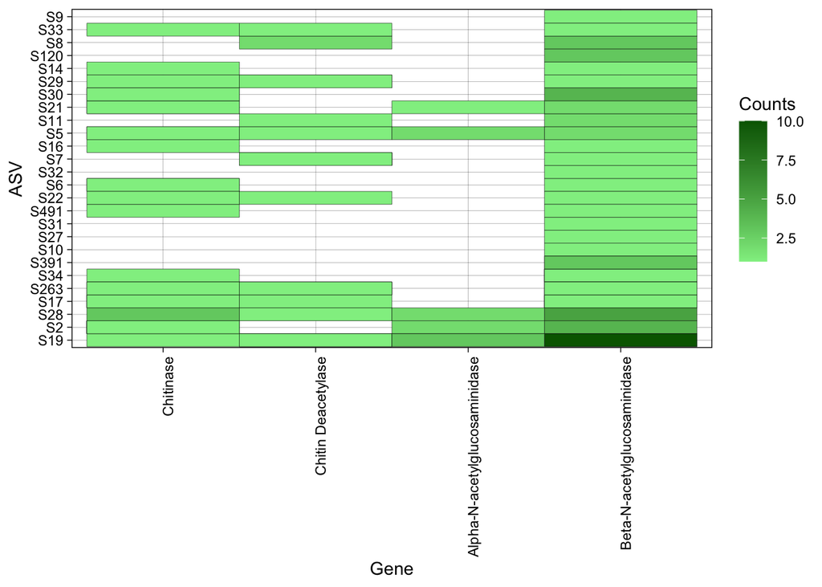

```r
#svglite("~/Desktop/PMXC_genome_chitin_heatmap.svg", height=10,width=6)
chit_plot
```

```r
#dev.off()
```

```r
# Convert OTU/ASV table to matrix
otu_mat7 <- as(otu_table(physeq_rel7), "matrix")
if (!taxa_are_rows(physeq_rel7)) {
  otu_mat7 <- t(otu_mat7)
}

# Convert to dataframe and add ASV column
otu_df7 <- as.data.frame(otu_mat7)
otu_df7$ASV <- rownames(otu_mat7)

# Extract sample metadata
meta_df7 <- as.data.frame(sample_data(physeq_rel7))

# Combine OTU/ASV table with metadata
# Left join so metadata lines up with samples
otu_meta_df7 <- cbind(meta_df7, t(otu_df7[, -ncol(otu_df7)]))

# Subset to samples with the desired treatments
otu_sub <- subset(otu_meta_df7, Treatment %in% c("SCRVTB", "SCRVTNB"))

# Keep only metadata + the two ASVs of interest
otu_sub <- otu_sub[, c("Treatment", "ASV17", "ASV2")]
```

#Abundance boxplot

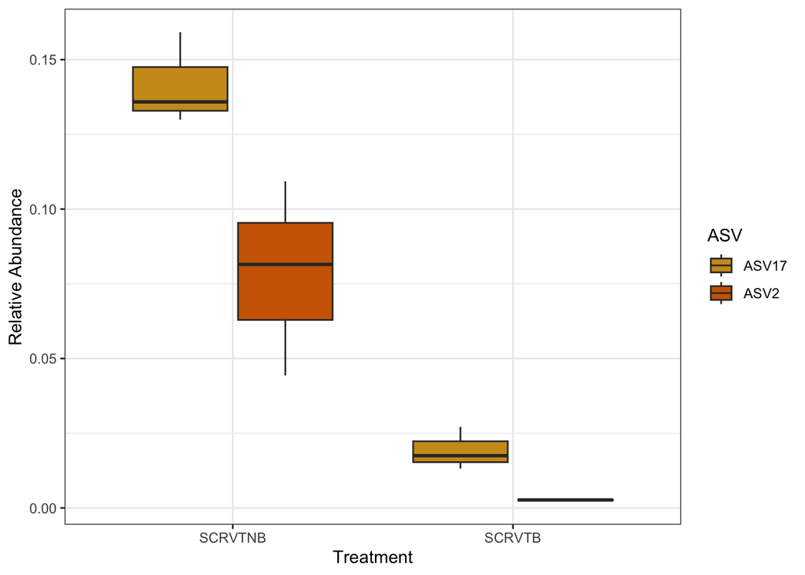

```r
library(ggplot2)
library(reshape2)  # or tidyr::pivot_longer

# Convert to long format (ASV + abundance in one column)
otu_long <- reshape2::melt(otu_sub, id.vars = "Treatment",
                 variable.name = "ASV",
                 value.name = "Abundance")

# Make boxplot

#svglite("~/Desktop/PMXC_pedo_plot.svg", height=6, width=6)

ggplot(otu_long, aes(x = Treatment, y = Abundance, fill = ASV)) +
  geom_boxplot() +
  theme_bw() +
  scale_fill_manual(
    values = c("ASV17" = "goldenrod3",
               "ASV2"  = "darkorange3")
  ) +
  ylab("Relative Abundance")
```

```r
#dev.off()
```

#Boxplot of abundances for S34, S14 and S29 in CR and M9 at T12

```r
# Convert OTU/ASV table to matrix
otu_mat7 <- as(otu_table(physeq_rel7), "matrix")
if (!taxa_are_rows(physeq_rel7)) {
  otu_mat7 <- t(otu_mat7)
}

# Convert to dataframe and add ASV column
otu_df7 <- as.data.frame(otu_mat7)
otu_df7$ASV <- rownames(otu_mat7)

# Extract sample metadata
meta_df7 <- as.data.frame(sample_data(physeq_rel7))

# Combine OTU/ASV table with metadata
# Left join so metadata lines up with samples
otu_meta_df7 <- cbind(meta_df7, t(otu_df7[, -ncol(otu_df7)]))



# Keep only metadata + the two ASVs of interest
otu_sub <- otu_meta_df7[, c("Treatment", "ASV34", "ASV14", "ASV29", "Media")]

# Convert to long format (ASV + abundance in one column)
otu_long <- reshape2::melt(otu_sub, id.vars = c("Treatment", "Media"),
                 variable.name = "ASV",
                 value.name = "Abundance")
```

# Make boxplot

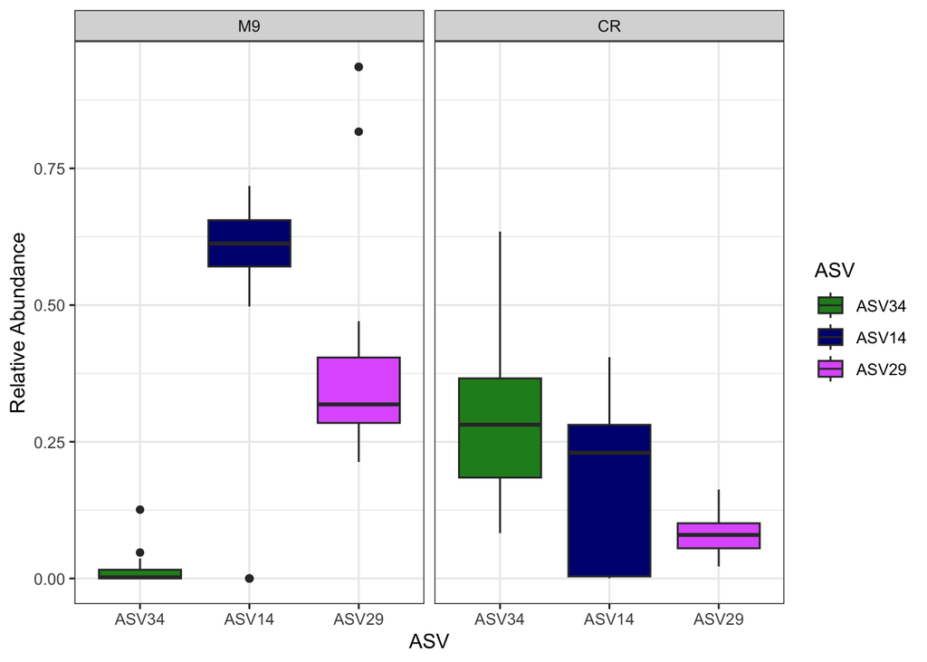

```r
#svglite("~/Desktop/PMXC_media_S34_S14_S29_plot.svg", height=6, width=6)

ggplot(otu_long, aes(x = ASV, y = Abundance, fill = ASV)) +
  geom_boxplot() +
  theme_bw() +
  scale_fill_manual(
    values = c("ASV34" = "forestgreen",
               "ASV14"  = "navy",
               "ASV29" = "mediumorchid1")
  ) +
  ylab("Relative Abundance") + facet_wrap(~Media)
```

```r
#dev.off()
```